# Customer lifecycle — executed notebook

# Customer Lifecycle, RFM & Retention — Remaster **Question:** Which historical customer histories justify retention, second-order or win-back tests, and which need credit/value review first? This walkthrough executes the same canonical pipeline as the CLI. There is no second set of segment rules or stale manually typed percentages. All customer audiences are hypotheses, not deployed campaigns. AI-assisted remaster; personal interview understanding remains a separate check.

```
from pathlib import Path
import importlib.util
import json
import pandas as pd
from IPython.display import display, Image
candidates = [Path.cwd(), Path.cwd() / "ecommerce_customer_segmentation_rfm", Path.cwd().parent]
ROOT = next((p.resolve() for p in candidates if (p / "analysis/run_analysis.py").is_file()), None)
if ROOT is None:
    raise RuntimeError("Open the notebook from the extracted project folder")
spec = importlib.util.spec_from_file_location("rfm_pipeline", ROOT / "analysis/run_analysis.py")
pipeline = importlib.util.module_from_spec(spec)
spec.loader.exec_module(pipeline)
def table(name):
    return pd.read_csv(ROOT / "outputs" / (name + ".csv"))
```

## 1. Source and grain Online Retail II is public historical transaction data from one UK retailer with wholesale customers. The bundled CSV was compared with the official UCI workbook; see DATA_SOURCES.md and audit/source_verification.json. One row is an invoice/product or charge line, not a customer/order. First observed purchase is not verified acquisition. Dates are source-local with no timezone metadata.

```
raw = pipeline.read_input(ROOT / "data/online_retail_II.csv.gz")
display(pd.DataFrame({"dtype": raw.dtypes.astype(str), "missing": raw.isna().sum()}))
display(raw.head(3))
print("Raw invoice lines:", len(raw))
```

|  | dtype | missing |
| --- | --- | --- |
| Invoice | string | 0 |
| StockCode | string | 0 |
| Description | object | 4382 |
| Quantity | int64 | 0 |
| InvoiceDate | object | 0 |
| Price | float64 | 0 |
| Customer ID | float64 | 243007 |
| Country | string | 0 |

|  | Invoice | StockCode | Description | Quantity | InvoiceDate | Price | Customer ID | Country |
| --- | --- | --- | --- | --- | --- | --- | --- | --- |
| 0 | 489434 | 85048 | 15CM CHRISTMAS GLASS BALL 20 LIGHTS | 12 | 2009-12-01 07:45:00 | 6.95 | 13085.0 | United Kingdom |
| 1 | 489434 | 79323P | PINK CHERRY LIGHTS | 12 | 2009-12-01 07:45:00 | 6.75 | 13085.0 | United Kingdom |
| 2 | 489434 | 79323W | WHITE CHERRY LIGHTS | 12 | 2009-12-01 07:45:00 | 6.75 | 13085.0 | United Kingdom |

## 2. Execute the complete pipeline Validate types/keys, preserve source lines, reconcile exclusions, distinguish purchases/credits, aggregate distinct invoices, score customer history, calculate complete repeat/cohort windows, and regenerate outputs/figures/memo. A failure is not a new successful delivery.

```
stats = pipeline.run_pipeline()
display(pd.DataFrame({"Metric": list(stats.keys()), "Value": [str(v) for v in stats.values()]}))
```

|  | Metric | Value |
| --- | --- | --- |
| 0 | version | remaster-1.0.2 |
| 1 | raw_rows | 1067371 |
| 2 | purchase_lines | 779425 |
| 3 | credit_lines | 18390 |
| 4 | orders | 36969 |
| 5 | customers | 5878 |
| 6 | gross_purchase_value_gbp | 17374804.268 |
| 7 | credit_value_gbp | 1023763.3100000003 |
| 8 | net_recorded_value_gbp | 16351040.958 |
| 9 | repeat_customer_rate | 0.7238856753997959 |
| 10 | repeat_another_day_rate | 0.7126573664511738 |
| 11 | eligible90_customers | 5281 |
| 12 | second_order90_customers | 2486 |
| 13 | repeat90_rate | 0.47074417723915923 |
| 14 | another_day90_rate | 0.44309789812535505 |
| 15 | median_days_to_second_among_repeaters | 55.96041666666667 |
| 16 | credit_review_customers | 73 |
| 17 | observation_start | 2009-12-01 07:45:00 |
| 18 | observation_end | 2011-12-09 12:50:00 |
| 19 | snapshot_date | 2011-12-10 |
| 20 | last_complete_month | 2011-11 |
| 21 | currency | GBP |
| 22 | timestamp_timezone | source-local naive; timezone unspecified |
| 23 | input_sha256 | 88703abba52824ab26c0f107fb8104637c5dc3a199c6cc... |
| 24 | config_sha256 | 3d03c4c3923177c2397f1c1edf1e64b1171a49940034bf... |

```
display(table("cleaning_reconciliation"))
display(table("value_reconciliation"))
display(table("data_quality_summary"))
```

|  | Stage | RowsAfter | SignedValueAfterGBP | UnpricedRowsAfter | RowsRemoved | SignedValueRemovedGBP |
| --- | --- | --- | --- | --- | --- | --- |
| 0 | Raw parsed | 1067371 | 19287250.57 | 0 | 0 | 0.00 |
| 1 | Missing customer ID | 824364 | 16648292.39 | 0 | 243007 | 2638958.18 |
| 2 | Invalid customer ID | 824364 | 16648292.39 | 0 | 0 | 0.00 |
| 3 | Invalid required value/date/key | 824364 | 16648292.39 | 0 | 0 | 0.00 |
| 4 | Zero/noninteger quantity | 824364 | 16648292.39 | 0 | 0 | 0.00 |
| 5 | Nonpositive price | 824293 | 16648292.39 | 0 | 71 | 0.00 |
| 6 | Inconsistent credit sign | 824293 | 16648292.39 | 0 | 0 | 0.00 |
| 7 | Exact duplicate raw rows | 797815 | 16289991.29 | 0 | 26478 | 358301.10 |

|  | Metric | GBP |
| --- | --- | --- |
| 0 | Signed identified value (purchase and credit-o... | 16289991.29 |
| 1 | Gross purchases of analysed customers | 17374804.27 |
| 2 | Credits of analysed customers | 1023763.31 |
| 3 | Net recorded value of analysed customers | 16351040.96 |
| 4 | Credit-only customer signed value (excluded fr... | -61049.67 |

|  | Check | Count | Meaning |
| --- | --- | --- | --- |
| 0 | Missing customer ID | 243007 | Overlapping input flag; do not sum as removals |
| 1 | Invalid customer ID | 0 | Overlapping input flag; do not sum as removals |
| 2 | Invalid required value/date/key | 243007 | Overlapping input flag; do not sum as removals |
| 3 | Zero/noninteger quantity | 0 | Overlapping input flag; do not sum as removals |
| 4 | Nonpositive price | 6207 | Overlapping input flag; do not sum as removals |
| 5 | Inconsistent credit sign | 3458 | Overlapping input flag; do not sum as removals |
| 6 | Exact duplicate raw rows | 34335 | Overlapping input flag; do not sum as removals |
| 7 | Parsing failures: Quantity | 0 | Nonblank source value failed parsing |
| 8 | Parsing failures: Price | 0 | Nonblank source value failed parsing |
| 9 | Parsing failures: Customer ID | 0 | Nonblank source value failed parsing |
| 10 | Parsing failures: InvoiceDate | 0 | Nonblank source value failed parsing |
| 11 | Missing Description | 4382 | Allowed: description is not used to infer buyi... |
| 12 | Invoices with multiple within-day timestamps | 64 | Earliest timestamp defines order; all lines re... |

## 3. RFM and lifecycle answer different questions RFM uses relative cutoffs with equal raw values receiving equal scores; repeated cutoffs may leave empty bands. R is calendar recency, F distinct positive invoices, M gross purchases minus recorded credits. RFM sum is descriptive, not an action optimizer. Lifecycle uses absolute 90/180-day rules and observed order count. See docs/METHODS.md for all rules and precedence. M affects active, at-risk and dormant treatments. Credit review overrides outreach. Relative labels do not prove loyalty or new acquisition.

```
display(table("rfm_cutoffs"))
display(table("rfm_segment_summary"))
display(table("lifecycle_summary"))
cols = ["Customer ID", "Orders", "PurchaseDays", "RecencyDays", "NetRecordedValueGBP", "RFM_Profile", "Lifecycle", "ValueTier", "CRM Priority"]
display(table("customer_lifecycle_table")[cols].head(8))
```

|  | Dimension | RawField | Quantile | Cutoff | TieRule |
| --- | --- | --- | --- | --- | --- |
| 0 | R | RecencyDays | 0.2 | 20.000 | Ascending bin uses value > cutoff; equal stays... |
| 1 | R | RecencyDays | 0.4 | 59.000 | Ascending bin uses value > cutoff; equal stays... |
| 2 | R | RecencyDays | 0.6 | 190.000 | Ascending bin uses value > cutoff; equal stays... |
| 3 | R | RecencyDays | 0.8 | 411.000 | Ascending bin uses value > cutoff; equal stays... |
| 4 | F | Orders | 0.2 | 1.000 | Ascending bin uses value > cutoff; equal stays... |
| 5 | F | Orders | 0.4 | 2.000 | Ascending bin uses value > cutoff; equal stays... |
| 6 | F | Orders | 0.6 | 4.000 | Ascending bin uses value > cutoff; equal stays... |
| 7 | F | Orders | 0.8 | 8.000 | Ascending bin uses value > cutoff; equal stays... |
| 8 | M | NetRecordedValueGBP | 0.2 | 266.796 | Ascending bin uses value > cutoff; equal stays... |
| 9 | M | NetRecordedValueGBP | 0.4 | 589.042 | Ascending bin uses value > cutoff; equal stays... |
| 10 | M | NetRecordedValueGBP | 0.6 | 1179.542 | Ascending bin uses value > cutoff; equal stays... |
| 11 | M | NetRecordedValueGBP | 0.8 | 2828.046 | Ascending bin uses value > cutoff; equal stays... |

|  | RFM Segment | Customers | GrossPurchaseValueGBP | CreditValueGBP | NetRecordedValueGBP | AverageRecencyDays | AverageOrders | MedianObservedTenureDays | CustomerSharePct | GrossValueSharePct |
| --- | --- | --- | --- | --- | --- | --- | --- | --- | --- | --- |
| 0 | Champions (relative) | 1268 | 1.179323e+07 | 432116.23 | 1.136111e+07 | 20.123028 | 17.370662 | 654.050694 | 21.571963 | 67.875451 |
| 1 | Recent frequent | 611 | 1.787092e+06 | 53643.01 | 1.733449e+06 | 86.793781 | 8.361702 | 643.840972 | 10.394692 | 10.285537 |
| 2 | Lapsed frequent | 704 | 1.517228e+06 | 219330.31 | 1.297898e+06 | 362.464489 | 5.433239 | 651.805903 | 11.976863 | 8.732347 |
| 3 | Recent mid-frequency | 711 | 8.674839e+05 | 191834.71 | 6.756492e+05 | 25.876231 | 2.884669 | 263.950694 | 12.095951 | 4.992769 |
| 4 | Lapsed low-frequency | 1639 | 7.230156e+05 | 71002.67 | 6.520129e+05 | 456.973154 | 1.305674 | 494.895833 | 27.883634 | 4.161288 |
| 5 | Intermediate | 708 | 6.062525e+05 | 54740.34 | 5.515122e+05 | 110.526836 | 2.233051 | 238.729514 | 12.044913 | 3.489262 |
| 6 | Recent low-frequency | 237 | 8.050544e+04 | 1096.04 | 7.940940e+04 | 30.468354 | 1.000000 | 28.995139 | 4.031984 | 0.463346 |

|  | Lifecycle | Customers | GrossPurchaseValueGBP | CreditValueGBP | NetRecordedValueGBP | AverageRecencyDays | AverageOrders | MedianObservedTenureDays | CustomerSharePct | GrossValueSharePct |
| --- | --- | --- | --- | --- | --- | --- | --- | --- | --- | --- |
| 0 | Active repeat | 2524 | 1.384482e+07 | 654086.39 | 1.319073e+07 | 30.448098 | 10.884707 | 554.084028 | 42.939775 | 79.683306 |
| 1 | Dormant | 2401 | 2.336812e+06 | 330748.48 | 2.006064e+06 | 422.717201 | 2.586422 | 553.911806 | 40.847227 | 13.449432 |
| 2 | At risk | 588 | 1.054571e+06 | 34965.09 | 1.019606e+06 | 133.001701 | 4.967687 | 521.948958 | 10.003403 | 6.069543 |
| 3 | Recent single-order | 365 | 1.386021e+05 | 3963.35 | 1.346387e+05 | 45.405479 | 1.000000 | 44.896528 | 6.209595 | 0.797719 |

|  | Customer ID | Orders | PurchaseDays | RecencyDays | NetRecordedValueGBP | RFM_Profile | Lifecycle | ValueTier | CRM Priority |
| --- | --- | --- | --- | --- | --- | --- | --- | --- | --- |
| 0 | 12346 | 12 | 8 | 326 | -51.74 | 251 | Dormant | Lower recorded value | Review credits before outreach |
| 1 | 12347 | 8 | 8 | 3 | 4921.53 | 545 | Active repeat | Higher recorded value | Protect frequent higher-value |
| 2 | 12348 | 5 | 5 | 76 | 2019.40 | 344 | Active repeat | Higher recorded value | Develop higher-value repeat |
| 3 | 12349 | 4 | 4 | 19 | 4404.54 | 535 | Active repeat | Higher recorded value | Develop higher-value repeat |
| 4 | 12350 | 1 | 1 | 311 | 334.40 | 212 | Dormant | Lower recorded value | Lower-cost dormant test |
| 5 | 12351 | 1 | 1 | 376 | 300.93 | 212 | Dormant | Lower recorded value | Lower-cost dormant test |
| 6 | 12352 | 10 | 9 | 37 | 1889.21 | 454 | Active repeat | Higher recorded value | Protect frequent higher-value |
| 7 | 12353 | 2 | 2 | 205 | 406.76 | 222 | Dormant | Lower recorded value | Lower-cost dormant test |

## 4. Repeat purchase: the right denominator and window All-history repeat has unequal follow-up. Mature 90-day repeat requires first timestamp + 90 elapsed days <= actual source end. A second invoice at day 90 plus one second is outside the window. Day 0 repeat is possible; compare the another-day definition. The cumulative curve uses the same mature denominator at every point. The repeaters-only median is not an optimal message day. Current RFM group versus historical first-repeat outcome would be circular, so no individual probability is assigned from that comparison.

```
display(table("repeat_90_curve"))
display(table("repeat_90_by_cohort"))
print("Mature 90-day second-order rate:", pipeline.fmt_rate(stats["repeat90_rate"]))
print("Different-day rate in same window:", pipeline.fmt_rate(stats["another_day90_rate"]))
print("Repeaters-only median elapsed days:", stats["median_days_to_second_among_repeaters"])
```

|  | Day | EligibleCustomers | SecondOrderCustomers | CumulativeRepeatRate |
| --- | --- | --- | --- | --- |
| 0 | 0 | 5281 | 7 | 0.001326 |
| 1 | 7 | 5281 | 507 | 0.096005 |
| 2 | 14 | 5281 | 767 | 0.145238 |
| 3 | 30 | 5281 | 1214 | 0.229881 |
| 4 | 60 | 5281 | 2003 | 0.379284 |
| 5 | 90 | 5281 | 2486 | 0.470744 |

|  | FirstObservedCohort | Customers | EligibleCustomers | SecondOrderCustomers | Repeat90Rate |
| --- | --- | --- | --- | --- | --- |
| 0 | 2009-12 | 955 | 955 | 587 | 0.614660 |
| 1 | 2010-01 | 383 | 383 | 201 | 0.524804 |
| 2 | 2010-02 | 374 | 374 | 197 | 0.526738 |
| 3 | 2010-03 | 443 | 443 | 195 | 0.440181 |
| 4 | 2010-04 | 294 | 294 | 120 | 0.408163 |
| 5 | 2010-05 | 254 | 254 | 94 | 0.370079 |
| 6 | 2010-06 | 270 | 270 | 107 | 0.396296 |
| 7 | 2010-07 | 186 | 186 | 83 | 0.446237 |
| 8 | 2010-08 | 162 | 162 | 87 | 0.537037 |
| 9 | 2010-09 | 243 | 243 | 112 | 0.460905 |
| 10 | 2010-10 | 377 | 377 | 153 | 0.405836 |
| 11 | 2010-11 | 325 | 325 | 114 | 0.350769 |
| 12 | 2010-12 | 76 | 76 | 12 | 0.157895 |
| 13 | 2011-01 | 71 | 71 | 29 | 0.408451 |
| 14 | 2011-02 | 124 | 124 | 40 | 0.322581 |
| 15 | 2011-03 | 179 | 179 | 76 | 0.424581 |
| 16 | 2011-04 | 106 | 106 | 42 | 0.396226 |
| 17 | 2011-05 | 111 | 111 | 49 | 0.441441 |
| 18 | 2011-06 | 108 | 108 | 54 | 0.500000 |
| 19 | 2011-07 | 102 | 102 | 58 | 0.568627 |
| 20 | 2011-08 | 106 | 106 | 54 | 0.509434 |
| 21 | 2011-09 | 189 | 32 | 22 | 0.687500 |
| 22 | 2011-10 | 221 | 0 | 0 | NaN |
| 23 | 2011-11 | 191 | 0 | 0 | NaN |
| 24 | 2011-12 | 28 | 0 | 0 | NaN |

## 5. Calendar-cohort activity Month n means a customer purchased in that calendar month, not continuously in all earlier months. Counts/rates exclude partial/future windows from headline metrics. Blank/grey is unobserved, not zero. The mature population changes with the horizon; the headline rates are not a survival curve.

```
display(table("retention_kpis"))
display(pd.read_csv(ROOT / "outputs/cohort_retention.csv").iloc[:, :8])
display(Image(filename=str(ROOT / "figures/cohort_retention_heatmap.png")))
display(Image(filename=str(ROOT / "figures/mature_cohort_rates.png")))
```

|  | Month | EligibleCohorts | EligibleCustomers | ActiveCustomers | WeightedRetentionRate |
| --- | --- | --- | --- | --- | --- |
| 0 | 1 | 23 | 5659 | 1327 | 0.234494 |
| 1 | 3 | 21 | 5249 | 1305 | 0.248619 |
| 2 | 6 | 18 | 4933 | 1089 | 0.220758 |
| 3 | 12 | 12 | 4266 | 968 | 0.226910 |

|  | CohortMonth | 0 | 1 | 2 | 3 | 4 | 5 | 6 |
| --- | --- | --- | --- | --- | --- | --- | --- | --- |
| 0 | 2009-12 | 1.0 | 0.352880 | 0.334031 | 0.425131 | 0.380105 | 0.359162 | 0.376963 |
| 1 | 2010-01 | 1.0 | 0.206266 | 0.310705 | 0.305483 | 0.263708 | 0.300261 | 0.258486 |
| 2 | 2010-02 | 1.0 | 0.237968 | 0.224599 | 0.291444 | 0.245989 | 0.200535 | 0.192513 |
| 3 | 2010-03 | 1.0 | 0.189616 | 0.230248 | 0.241535 | 0.232506 | 0.203160 | 0.246050 |
| 4 | 2010-04 | 1.0 | 0.193878 | 0.193878 | 0.163265 | 0.183673 | 0.224490 | 0.275510 |
| 5 | 2010-05 | 1.0 | 0.157480 | 0.169291 | 0.173228 | 0.177165 | 0.255906 | 0.212598 |
| 6 | 2010-06 | 1.0 | 0.174074 | 0.188889 | 0.203704 | 0.229630 | 0.285185 | 0.125926 |
| 7 | 2010-07 | 1.0 | 0.155914 | 0.182796 | 0.295699 | 0.290323 | 0.139785 | 0.112903 |
| 8 | 2010-08 | 1.0 | 0.203704 | 0.296296 | 0.320988 | 0.172840 | 0.117284 | 0.098765 |
| 9 | 2010-09 | 1.0 | 0.226337 | 0.234568 | 0.123457 | 0.090535 | 0.102881 | 0.135802 |
| 10 | 2010-10 | 1.0 | 0.257294 | 0.145889 | 0.124668 | 0.087533 | 0.082228 | 0.129973 |
| 11 | 2010-11 | 1.0 | 0.175385 | 0.092308 | 0.095385 | 0.076923 | 0.086154 | 0.129231 |
| 12 | 2010-12 | 1.0 | 0.092105 | 0.052632 | 0.092105 | 0.118421 | 0.065789 | 0.052632 |
| 13 | 2011-01 | 1.0 | 0.169014 | 0.211268 | 0.197183 | 0.211268 | 0.154930 | 0.154930 |
| 14 | 2011-02 | 1.0 | 0.161290 | 0.153226 | 0.185484 | 0.217742 | 0.153226 | 0.153226 |
| 15 | 2011-03 | 1.0 | 0.184358 | 0.217877 | 0.201117 | 0.223464 | 0.150838 | 0.206704 |
| 16 | 2011-04 | 1.0 | 0.254717 | 0.198113 | 0.198113 | 0.179245 | 0.235849 | 0.179245 |
| 17 | 2011-05 | 1.0 | 0.234234 | 0.243243 | 0.162162 | 0.216216 | 0.207207 | 0.261261 |
| 18 | 2011-06 | 1.0 | 0.231481 | 0.212963 | 0.268519 | 0.203704 | 0.287037 | NaN |
| 19 | 2011-07 | 1.0 | 0.215686 | 0.303922 | 0.274510 | 0.343137 | NaN | NaN |
| 20 | 2011-08 | 1.0 | 0.273585 | 0.311321 | 0.264151 | NaN | NaN | NaN |
| 21 | 2011-09 | 1.0 | 0.269841 | 0.375661 | NaN | NaN | NaN | NaN |
| 22 | 2011-10 | 1.0 | 0.321267 | NaN | NaN | NaN | NaN | NaN |
| 23 | 2011-11 | 1.0 | NaN | NaN | NaN | NaN | NaN | NaN |
| 24 | 2011-12 | NaN | NaN | NaN | NaN | NaN | NaN | NaN |

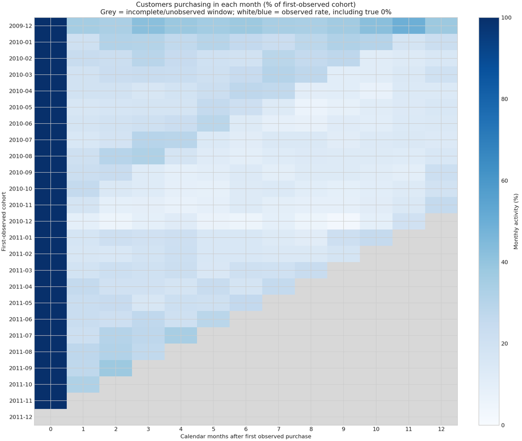

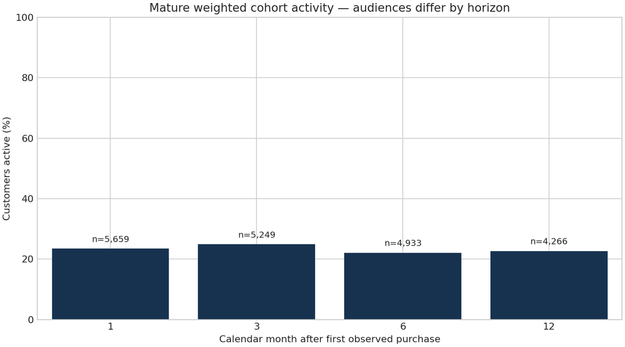

## 6. Combine the evidence into proposed tests Lifecycle selects the journey; value/frequency/Champion context differentiate the historical audience; credits can require review first. Repeat/cohort metrics provide aggregate context and test baselines, not causal impact or individual response probabilities. All ContactReady flags are false: source IDs are not consent/contact records.

```
display(table("crm_priority_summary"))
display(table("rfm_lifecycle_crosswalk"))
display(Image(filename=str(ROOT / "figures/customer_lifecycle_decision_dashboard.png")))
```

|  | CRM Priority | Customers | GrossPurchaseValueGBP | CreditValueGBP | NetRecordedValueGBP | AverageRecencyDays | AverageOrders | MedianObservedTenureDays | CustomerSharePct | GrossValueSharePct |
| --- | --- | --- | --- | --- | --- | --- | --- | --- | --- | --- |
| 0 | Protect frequent higher-value | 1266 | 1.175935e+07 | 406827.82 | 1.135252e+07 | 20.097156 | 17.387046 | 654.050694 | 21.537938 | 67.680471 |
| 1 | Develop higher-value repeat | 409 | 1.272535e+06 | 23496.71 | 1.249039e+06 | 54.777506 | 6.246944 | 522.000694 | 6.958149 | 7.324027 |
| 2 | Review dormant higher-value | 404 | 1.262036e+06 | 50576.08 | 1.211460e+06 | 356.945545 | 6.284653 | 653.066319 | 6.873086 | 7.263596 |
| 3 | Lower-cost dormant test | 1947 | 8.114553e+05 | 18824.72 | 7.926306e+05 | 435.699538 | 1.821263 | 528.016667 | 33.123511 | 4.670299 |
| 4 | Win-back frequent higher-value test | 189 | 7.353960e+05 | 25494.14 | 7.099019e+05 | 126.063492 | 9.645503 | 659.950694 | 3.215379 | 4.232543 |
| 5 | Develop repeat relationship | 836 | 5.864003e+05 | 11768.42 | 5.746319e+05 | 34.149522 | 3.406699 | 374.904861 | 14.222525 | 3.375004 |
| 6 | Review credits before outreach | 73 | 4.965238e+05 | 479042.59 | 1.748121e+04 | 324.000000 | 2.739726 | 444.847222 | 1.241919 | 2.857723 |
| 7 | Lower-cost win-back test | 332 | 1.824441e+05 | 4106.07 | 1.783380e+05 | 136.578313 | 2.662651 | 268.472222 | 5.648180 | 1.050050 |
| 8 | Second-order journey test | 358 | 1.356339e+05 | 995.12 | 1.346387e+05 | 45.156425 | 1.000000 | 44.068750 | 6.090507 | 0.780635 |
| 9 | Win-back higher-value test | 64 | 1.330306e+05 | 2631.64 | 1.303989e+05 | 135.562500 | 3.187500 | 551.034028 | 1.088806 | 0.765652 |

|  | RFM Segment | Lifecycle | ValueTier | CRM Priority | Customers |
| --- | --- | --- | --- | --- | --- |
| 0 | Champions (relative) | Active repeat | Higher recorded value | Protect frequent higher-value | 1266 |
| 1 | Champions (relative) | Active repeat | Higher recorded value | Review credits before outreach | 2 |
| 2 | Intermediate | Active repeat | Higher recorded value | Develop higher-value repeat | 59 |
| 3 | Intermediate | Active repeat | Lower recorded value | Develop repeat relationship | 58 |
| 4 | Intermediate | Active repeat | Lower recorded value | Review credits before outreach | 1 |
| 5 | Intermediate | Active repeat | Middle recorded value | Develop repeat relationship | 72 |
| 6 | Intermediate | At risk | Higher recorded value | Win-back higher-value test | 64 |
| 7 | Intermediate | At risk | Lower recorded value | Lower-cost win-back test | 184 |
| 8 | Intermediate | At risk | Lower recorded value | Review credits before outreach | 2 |
| 9 | Intermediate | At risk | Middle recorded value | Lower-cost win-back test | 105 |
| 10 | Intermediate | Dormant | Higher recorded value | Review dormant higher-value | 3 |
| 11 | Intermediate | Dormant | Lower recorded value | Lower-cost dormant test | 24 |
| 12 | Intermediate | Dormant | Lower recorded value | Review credits before outreach | 1 |
| 13 | Intermediate | Dormant | Middle recorded value | Lower-cost dormant test | 6 |
| 14 | Intermediate | Dormant | Middle recorded value | Review credits before outreach | 1 |
| 15 | Intermediate | Recent single-order | Higher recorded value | Second-order journey test | 7 |
| 16 | Intermediate | Recent single-order | Lower recorded value | Review credits before outreach | 5 |
| 17 | Intermediate | Recent single-order | Lower recorded value | Second-order journey test | 101 |
| 18 | Intermediate | Recent single-order | Middle recorded value | Second-order journey test | 15 |
| 19 | Lapsed frequent | Dormant | Higher recorded value | Review credits before outreach | 4 |
| 20 | Lapsed frequent | Dormant | Higher recorded value | Review dormant higher-value | 318 |
| 21 | Lapsed frequent | Dormant | Lower recorded value | Lower-cost dormant test | 122 |
| 22 | Lapsed frequent | Dormant | Lower recorded value | Review credits before outreach | 8 |
| 23 | Lapsed frequent | Dormant | Middle recorded value | Lower-cost dormant test | 251 |
| 24 | Lapsed frequent | Dormant | Middle recorded value | Review credits before outreach | 1 |
| 25 | Lapsed low-frequency | Dormant | Higher recorded value | Review dormant higher-value | 71 |
| 26 | Lapsed low-frequency | Dormant | Lower recorded value | Lower-cost dormant test | 1324 |
| 27 | Lapsed low-frequency | Dormant | Lower recorded value | Review credits before outreach | 34 |
| 28 | Lapsed low-frequency | Dormant | Middle recorded value | Lower-cost dormant test | 209 |
| 29 | Lapsed low-frequency | Dormant | Middle recorded value | Review credits before outreach | 1 |
| 30 | Recent frequent | Active repeat | Higher recorded value | Develop higher-value repeat | 190 |
| 31 | Recent frequent | Active repeat | Lower recorded value | Develop repeat relationship | 10 |
| 32 | Recent frequent | Active repeat | Lower recorded value | Review credits before outreach | 2 |
| 33 | Recent frequent | Active repeat | Middle recorded value | Develop repeat relationship | 152 |
| 34 | Recent frequent | Active repeat | Middle recorded value | Review credits before outreach | 1 |
| 35 | Recent frequent | At risk | Higher recorded value | Win-back frequent higher-value test | 189 |
| 36 | Recent frequent | At risk | Lower recorded value | Lower-cost win-back test | 7 |
| 37 | Recent frequent | At risk | Middle recorded value | Lower-cost win-back test | 36 |
| 38 | Recent frequent | At risk | Middle recorded value | Review credits before outreach | 1 |
| 39 | Recent frequent | Dormant | Higher recorded value | Review dormant higher-value | 12 |
| 40 | Recent frequent | Dormant | Lower recorded value | Lower-cost dormant test | 1 |
| 41 | Recent frequent | Dormant | Middle recorded value | Lower-cost dormant test | 10 |
| 42 | Recent low-frequency | Recent single-order | Higher recorded value | Second-order journey test | 5 |
| 43 | Recent low-frequency | Recent single-order | Lower recorded value | Review credits before outreach | 2 |
| 44 | Recent low-frequency | Recent single-order | Lower recorded value | Second-order journey test | 207 |
| 45 | Recent low-frequency | Recent single-order | Middle recorded value | Second-order journey test | 23 |
| 46 | Recent mid-frequency | Active repeat | Higher recorded value | Develop higher-value repeat | 160 |
| 47 | Recent mid-frequency | Active repeat | Higher recorded value | Review credits before outreach | 1 |
| 48 | Recent mid-frequency | Active repeat | Lower recorded value | Develop repeat relationship | 252 |
| 49 | Recent mid-frequency | Active repeat | Lower recorded value | Review credits before outreach | 6 |
| 50 | Recent mid-frequency | Active repeat | Middle recorded value | Develop repeat relationship | 292 |

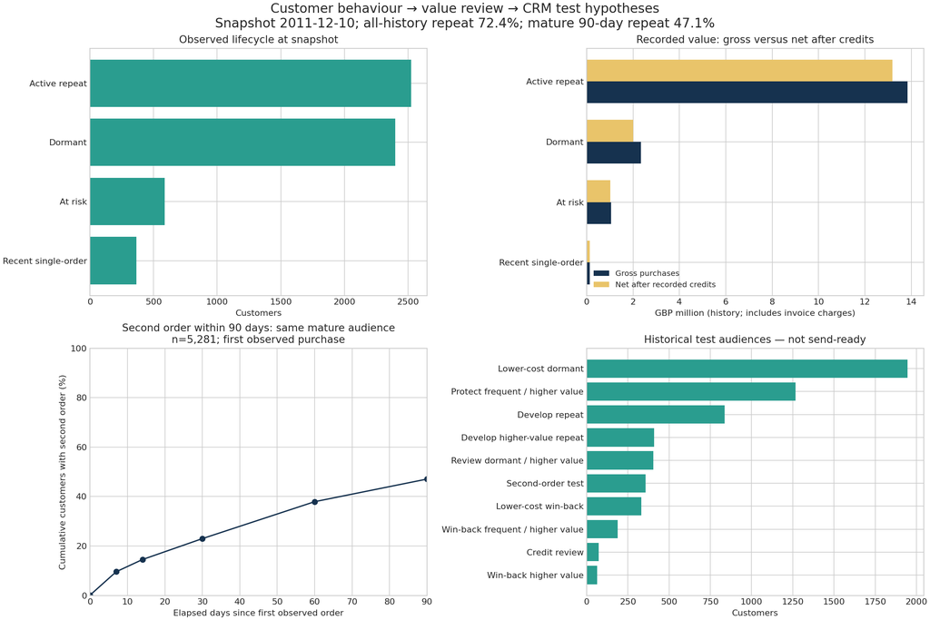

## 7. Sensitivity, business interpretation and limits Lifetime F/M depend on observation tenure, and source duplicates have no unique line IDs. Test alternate lifecycle/value/credit rules and examine 365-day context. These checks expose dependence on assumptions; they do not validate optimal cutoffs, future value, campaign ROI or profitable discounting.

```
display(table("rule_sensitivity"))
display(table("tenure_context"))
print((ROOT / "memo/business_memo.md").read_text())
```

|  | Variant | ActiveDays | DormantDays | HighValueMinMScore | CreditReviewRatio | ChangedActions | AtRiskCustomers | CreditReviewCustomers | HigherValueCustomers |
| --- | --- | --- | --- | --- | --- | --- | --- | --- | --- |
| 0 | base | 90 | 180 | 4 | 0.50 | 0 | 588 | 73 | 2351 |
| 1 | shorter lifecycle | 60 | 120 | 4 | 0.50 | 863 | 742 | 73 | 2351 |
| 2 | longer lifecycle | 120 | 240 | 4 | 0.50 | 529 | 667 | 73 | 2351 |
| 3 | higher value stricter | 90 | 180 | 5 | 0.50 | 1163 | 588 | 73 | 1176 |
| 4 | credit review earlier | 90 | 180 | 4 | 0.25 | 78 | 588 | 151 | 2351 |
| 5 | credit review later | 90 | 180 | 4 | 0.75 | 20 | 588 | 53 | 2351 |

|  | TenureBand | Customers | MeanAllHistoryOrders | MeanLast365DayOrders | MedianAllHistoryNetGBP | MedianLast365DayNetGBP |
| --- | --- | --- | --- | --- | --- | --- |
| 0 | 0-90 days | 597 | 1.778894 | 1.778894 | 378.89 | 380.13 |
| 1 | >90-365 days | 970 | 3.083505 | 3.082474 | 559.79 | 556.09 |
| 2 | >365 days | 4311 | 7.635351 | 3.178845 | 1075.59 | 285.67 |

## 8. What was actually verified? Run the documented fixture tests and independent SQL validator for semantic checks. The delivered audit records the tested input/version and scope. The notebook runs through a fresh Jupyter kernel; browser/frontend behaviour is not certified. This project is a historical descriptive exercise, not current Vietnam market research or a measured marketing campaign. Read docs/LEARNING_GUIDE_VI.md for the six-pillar explanation and docs/CONTRIBUTION.md before using this project in an interview. A runnable notebook does not prove personal mastery.